# Build Target

As a recap, the training data, validation data and test data contain information on physicists who were eligible to receive a Nobel Prize in Physics. That is, they were alive on and after 10 December 1901, the date the prize was first awarded.

All of the physicists in the training data are deceased and all the physicists in the validation and test data are alive. Recall that the Nobel Prize in Physics cannot be awarded posthumously and one of the goals of this project is to try to predict the next Physics Nobel Laureates. As a result, the data was purposely sampled in this way, so that the training set can be used to build models, which predict whether a living physicist is likely to be awarded the Nobel Prize in Physics.

It is time to use the training, validation and test data, along with the Nobel Physics Laureates data, to create the target that indicates whether a physicist is a Physics Nobel Laureate.

```python
import matplotlib.pyplot as plt
import numpy as np
import pandas as pd

%matplotlib inline
```

## Reading in the Data

First let's read in the training, validation and test data and the list of Nobel Physics Laureates.

```python
train_physicists = pd.read_csv('../data/processed/train-physicists-from-1901.csv')
train_physicists.head()
```

|  | abstract | academicAdvisor | almaMater | award | birthDate | birthName | birthPlace | categories | child | citizenship | ... | surname | theorized | thesisTitle | thesisUrl | thesisYear | thumbnail | wasDerivedFrom | wikiPageID | wikiPageRevisionID | workplaces |
| --- | --- | --- | --- | --- | --- | --- | --- | --- | --- | --- | --- | --- | --- | --- | --- | --- | --- | --- | --- | --- | --- |
| 0 | Aage Niels Bohr (Danish: [ˈɔːʊ̯ə ˌnels ˈboɐ̯ˀ]... | NaN | University of Copenhagen | Atoms for Peace Award\|Dannie Heineman Prize fo... | 1922-06-19 | NaN | Copenhagen | 1922 births\|2009 deaths\|Atoms for Peace Award ... | NaN | NaN | ... | NaN | NaN | Rotational States of Atomic Nuclei | NaN | 1954 | http://commons.wikimedia.org/wiki/Special:File... | http://en.wikipedia.org/wiki/Aage_Bohr?oldid=7... | 2201 | 727860526 | Columbia University\|Institute for Advanced Stu... |
| 1 | Aaldert Hendrik Wapstra (24 April 1922, Utrech... | NaN | NaN | International Union of Pure and Applied Physics | 1922-04-24 | NaN | NaN | 1922 births\|2006 deaths\|Delft University of Te... | NaN | NaN | ... | Wapstra | NaN | NaN | NaN | NaN | http://commons.wikimedia.org/wiki/Special:File... | http://en.wikipedia.org/wiki/Aaldert_Wapstra?o... | 11543116 | 717669775 | NaN |
| 2 | Mohammad Abdus Salam NI, SPk, KBE (Punjabi, Ur... | Paul Taunton Matthews | Government College University (Lahore)\|St John... | Adams Prize\|Atoms for Peace Award\|Copley Medal... | 1926-01-29 | NaN | Jhang\|Presidencies and provinces of British In... | 1926 births\|1996 deaths\|Academics of Imperial ... | Anisa Bushra Salam Bajwa\|Aziza Rahman | NaN | ... | NaN | W and Z bosons | Renormalisation of Quantum Field Theory | NaN | 1951 | http://commons.wikimedia.org/wiki/Special:File... | http://en.wikipedia.org/wiki/Abdus_Salam?oldid... | 304427 | 742242509 | PAECSUPARCOPINSTECHPunjab UniversityImperial C... |
| 3 | Abraham Isahakovich Alikhanov (Alikhanian, Arm... | NaN | Peter the Great St. Petersburg Polytechnic Uni... | Hero of Socialist Labour\|USSR State Prize | 1904-02-20 | NaN | Elisabethpol Governorate\|Ganja, Azerbaijan\|Rus... | 1904 births\|1970 deaths\|20th-century physicist... | NaN | NaN | ... | Alikhanov | NaN | NaN | NaN | NaN | NaN | http://en.wikipedia.org/wiki/Abraham_Alikhanov... | 18594585 | 736856447 | Institute for Theoretical and Experimental Phy... |
| 4 | Abraham Haskel Taub (February 1, 1911 – August... | NaN | Princeton University | NaN | 1911-02-01 | NaN | Chicago | 1911 births\|1999 deaths\|20th-century American ... | NaN | NaN | ... | NaN | NaN | NaN | NaN | NaN | http://commons.wikimedia.org/wiki/Special:File... | http://en.wikipedia.org/wiki/Abraham_H._Taub?o... | 2402789 | 742301006 | NaN |

5 rows × 43 columns

```python
validation_physicists = pd.read_csv('../data/processed/validation-physicists-from-1901.csv')
validation_physicists.head()
```

|  | abstract | academicAdvisor | almaMater | award | birthDate | birthName | birthPlace | categories | child | citizenship | ... | surname | theorized | thesisTitle | thesisUrl | thesisYear | thumbnail | wasDerivedFrom | wikiPageID | wikiPageRevisionID | workplaces |
| --- | --- | --- | --- | --- | --- | --- | --- | --- | --- | --- | --- | --- | --- | --- | --- | --- | --- | --- | --- | --- | --- |
| 0 | Abdul Qadeer Khan, NI, HI, FPAS /ˌɑːbˈdʊl kɑːd... | NaN | Catholic University of Leuven (1834–1968)\|Delf... | Hilal-i-Imtiaz\|Nishan-e-Imtiaz | 1936-04-27 | NaN | Bhopal\|India\|Princely state | 1936 births\|Catholic University of Leuven alum... | NaN | Pakistan | ... | NaN | NaN | NaN | NaN | NaN | NaN | http://en.wikipedia.org/wiki/Abdul_Qadeer_Khan... | 452160 | 742343533 | Ghulam Ishaq Khan Institute of Engineering Sci... |
| 1 | Alain Haché (born 14 December 1970, in Tracadi... | NaN | Université de Moncton\|University of Toronto | NaN | 1970-12-14 | NaN | New Brunswick\|Tracadie–Sheila | 1970 births\|Canada Research Chairs\|Canadian ph... | NaN | Canadians | ... | Haché | NaN | NaN | NaN | NaN | NaN | http://en.wikipedia.org/wiki/Alain_Haché?oldid... | 14597914 | 742996887 | Université de Moncton |
| 2 | Alan Andrew Watson, FRS, (born 26 September 19... | NaN | University of Edinburgh | NaN | 1938-09-26 | NaN | NaN | 1938 births\|Academics of the University of Lee... | NaN | British | ... | Watson | NaN | Physics of Condensation of Water Vapour | NaN | 1964.0 | http://commons.wikimedia.org/wiki/Special:File... | http://en.wikipedia.org/wiki/Alan_Andrew_Watso... | 27458583 | 718263511 | University of Leeds |
| 3 | Alan Harvey Guth (born February 27, 1947) is a... | NaN | Massachusetts Institute of Technology | Dirac Medal\|Franklin Medal\|Fundamental Physics... | 1947-02-27 | NaN | New Brunswick\|New Brunswick, New Jersey | 1947 births\|American astronomers\|American phys... | NaN | NaN | ... | Guth | NaN | NaN | NaN | NaN | http://commons.wikimedia.org/wiki/Special:File... | http://en.wikipedia.org/wiki/Alan_Guth?oldid=7... | 454498 | 734702685 | NaN |
| 4 | Albert Fert (born 7 March 1938) is a French ph... | NaN | École normale supérieure\|University of Paris | CNRS Gold medal\|Japan Prize\|Nobel Prize in Phy... | 1938-03-07 | NaN | Aude\|Carcassonne\|France | 1938 births\|École Normale Supérieure alumni\|Fr... | NaN | NaN | ... | Fert | NaN | NaN | NaN | NaN | http://commons.wikimedia.org/wiki/Special:File... | http://en.wikipedia.org/wiki/Albert_Fert?oldid... | 1810816 | 743347991 | Michigan State University\|National Autonomous ... |

5 rows × 43 columns

```python
# The double t naming of "ttest_" variables in this file is for testing purposes. When `ipytest` cleans the
# tests it deletes ANY object in the global namespace that begins with "test_", not just functions.
ttest_physicists = pd.read_csv('../data/processed/test-physicists-from-1901.csv')
ttest_physicists.head()
```

[output not shown]

5 rows × 43 columns

```python
nobel_physicists = pd.read_csv('../data/raw/nobel-physics-prize-laureates.csv')
nobel_physicists.head()
```

|  | Year | Laureate | Country | Rationale |
| --- | --- | --- | --- | --- |
| 0 | 1901 | Wilhelm Röntgen | German Empire | "in recognition of the extraordinary services ... |
| 1 | 1902 | Hendrik Lorentz | Netherlands | "in recognition of the extraordinary service t... |
| 2 | 1902 | Pieter Zeeman | Netherlands | "in recognition of the extraordinary service t... |
| 3 | 1903 | Henri Becquerel | France | "for his discovery of spontaneous radioactivity" |
| 4 | 1903 | Pierre Curie | France | "for their joint researches on the radiation p... |

## Creating the Target

It is now time to create the target from our data.

```python
def build_target(full_name, laureate):

    """Build the target variable indicating whether the physicist is a Nobel Laureate or not.

    Args:
        full_name (pandas.Series): Full name of physicist.
        laureate (pandas.Series): Full name of Physics Nobel Laureate.

    Returns:
        pandas.Series: Target variable indicating whether the physicist is a Nobel Laureate or not.

        """

    target = full_name.to_frame(name='full_name')
    target['physics_laureate'] = target.full_name.apply(
        lambda name: name in laureate.values).map({True: 'yes', False: 'no'})
    target = target.set_index('full_name')['physics_laureate']
    return target
```

```python
train_target = build_target(train_physicists.fullName, nobel_physicists.Laureate)
assert((len(train_target) == len(train_physicists)))
assert(isinstance(train_target, pd.core.series.Series))
assert((train_target == 'yes').sum() == 123)
assert(all(train_target.notna()))
train_target.head()
```

```
full_name
Aage Bohr            yes
Aaldert Wapstra       no
Abdus Salam          yes
Abraham Alikhanov     no
Abraham H. Taub       no
Name: physics_laureate, dtype: object
```

```python
validation_target = build_target(validation_physicists.fullName, nobel_physicists.Laureate)
assert((len(validation_target) == len(validation_physicists)))
assert(isinstance(validation_target, pd.core.series.Series))
assert((validation_target == 'yes').sum() == 41)
assert(all(validation_target.notna()))
validation_target.head()
```

```
full_name
Abdul Qadeer Khan      no
Alain Haché            no
Alan Andrew Watson     no
Alan Guth              no
Albert Fert           yes
Name: physics_laureate, dtype: object
```

```python
ttest_target = build_target(ttest_physicists.fullName, nobel_physicists.Laureate)
assert((len(ttest_target) == len(ttest_physicists)))
assert(isinstance(ttest_target, pd.core.series.Series))
assert((ttest_target == 'yes').sum() == 42)
assert(all(ttest_target.notna()))
ttest_target.head()
```

```
full_name
A. P. Balachandran     no
Adam Riess            yes
Adrian Melott          no
Alain Aspect           no
Alejandro Corichi      no
Name: physics_laureate, dtype: object
```

So what percentage of the physicists in each of the dataframes are laureates?

```python
training_fraction = (train_target == 'yes').sum() / len(train_target)
validation_fraction = (validation_target == 'yes').sum() / len(validation_target)
ttest_fraction = (ttest_target == 'yes').sum() / len(ttest_target)
laureate_fraction = pd.Series(
    data=[round(100 * training_fraction, 1), round(100 * validation_fraction, 1),
          round(100 * ttest_fraction, 1)],
    index=['Training', 'Validation', 'Test']
)
```

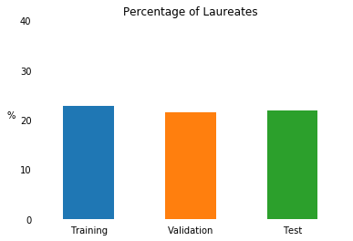

```python
ax = laureate_fraction.plot(kind='bar', title='Percentage of Laureates')
ax.set_ylabel('%', labelpad=10, rotation='horizontal')
ax.set_yticks(ticks=np.linspace(0, 40, num=5))
ax.tick_params(left=False, bottom=False)
plt.xticks(rotation=0)
plt.box(False)
```

This looks like a well balanced proportion of laureates in each of the datasets. There are no real surprises here as it's obvious there are more non-laureates than laureates. Naturally, due to the class imbalance, an appropriate metric for selecting and evaluating models will need to be chosen.

## Persisting the Data

Now we have the training, validation and test target series, we will persist them for future use.

```python
train_target.to_csv('../data/processed/train-target.csv', header=True)
validation_target.to_csv('../data/processed/validation-target.csv', header=True)
ttest_target.to_csv('../data/processed/test-target.csv', header=True)
```